# 30535 Skills Problem Set 1

Hye-Min Jung (github ID: hmjung-cpu)

4/10/2020

This submission is my work alone and complies with the 30535 integrity policy. **Hye-Min Jung**  
Collaborators: 4/8, additional O/H(Ari Anisfeld) and other 4 students (8:00~8:30pm)  
Late coins used this pset: 0. Late coins left: 4.

#### 1. Setup

##### 1.1 Installation

```r
library(tidyverse)
```

```r
install.packages(setdiff(c("ggplot2", "Rcpp"), rownames(installed.packages())))
unavailable <- setdiff(c("ggplot2", "Rcpp"), rownames(installed.packages()))
install.packages(unavailable)
```

#### 2. R for Data Science Exercises

##### 2.1 First steps

##### 1. How many rows are in mpg? How many columns? What do the rows represent? How about the columns?

- – *234 rows represent total observation number, 11 columns represent features of car model*

```r
data("mpg")
nrow(mpg);ncol(mpg)
```

```
## [1] 234
```

```
## [1] 11
```

```r
rownames(mpg);colnames(mpg)
```

[output not shown]

```
##  [1] "manufacturer" "model"        "displ"        "year"
##  [5] "cyl"          "trans"        "drv"          "cty"
##  [9] "hwy"          "fl"           "class"
```

##### 2. Make a scatterplot of hwy vs cyl.

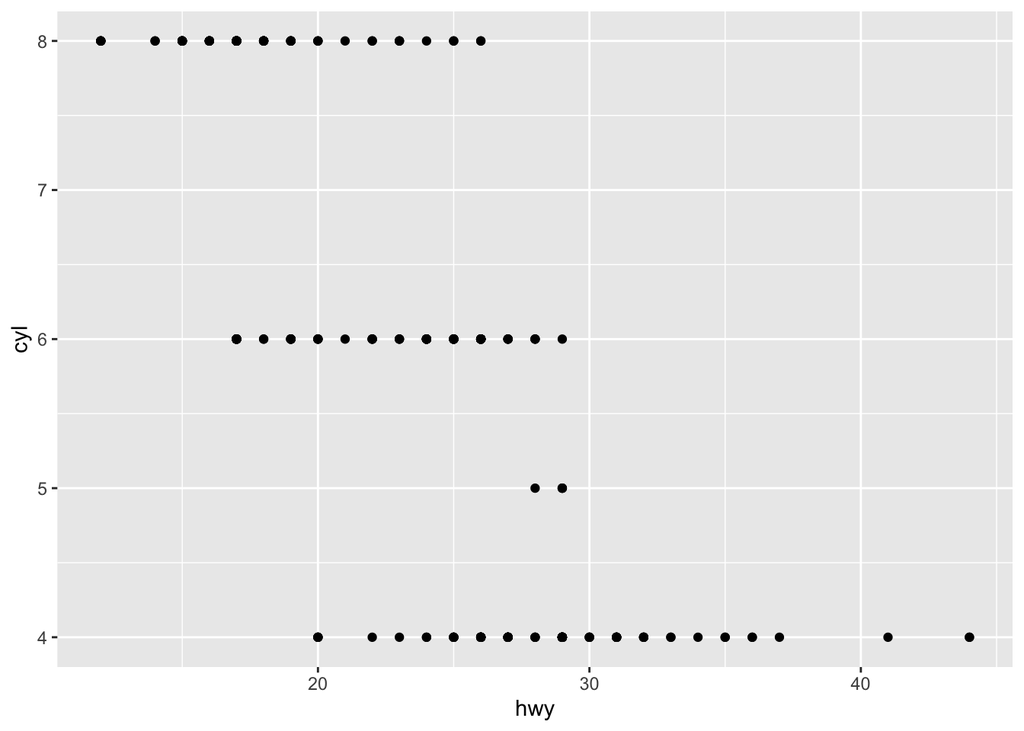

```r
ggplot(data = mpg) +
  geom_point(mapping = aes(x = hwy, y = cyl))
```

##### 3. What does the drv variable describe? Read the help for ?mpg to find out.

– *f = front-wheel drive, r = rear wheel drive, 4 = 4wd*

##### 4. What happens if you make a scatterplot of class vs drv? Why is the plot not useful?

– *The graph only shows the existing combinations of categorical variables “classXdrv”. It’s not useful because it does not show the density of each combinations. It would be giving more information if drawn on 3-dimensional graph to see the densities for each combination of the categorical variables*

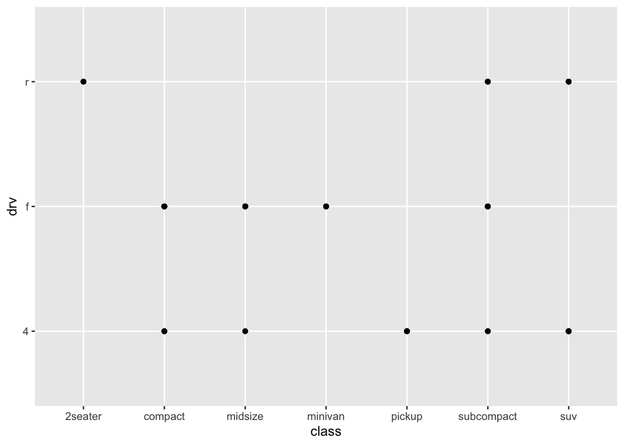

```r
ggplot(data = mpg) +
  geom_point(mapping = aes(x = class, y = drv))
```

##### 2.2 Grammar of graphics : Mapping data to aesthetics

- – *Generally it depends on what your data is.*

  – *Generally speaking, “chr” categorical variable “int” categorical/continuous variable “dbl” continuous variable*

  – *One should be cautious because, year for example is treated as integer but it is actually categorical variable*

```r
print(mpg)
```

```
## # A tibble: 234 x 11
##    manufacturer model displ  year   cyl trans drv     cty   hwy fl    class
##    <chr>        <chr> <dbl> <int> <int> <chr> <chr> <int> <int> <chr> <chr>
##  1 audi         a4      1.8  1999     4 auto… f        18    29 p     comp…
##  2 audi         a4      1.8  1999     4 manu… f        21    29 p     comp…
##  3 audi         a4      2    2008     4 manu… f        20    31 p     comp…
##  4 audi         a4      2    2008     4 auto… f        21    30 p     comp…
##  5 audi         a4      2.8  1999     6 auto… f        16    26 p     comp…
##  6 audi         a4      2.8  1999     6 manu… f        18    26 p     comp…
##  7 audi         a4      3.1  2008     6 auto… f        18    27 p     comp…
##  8 audi         a4 q…   1.8  1999     4 manu… 4        18    26 p     comp…
##  9 audi         a4 q…   1.8  1999     4 auto… 4        16    25 p     comp…
## 10 audi         a4 q…   2    2008     4 manu… 4        20    28 p     comp…
## # … with 224 more rows
```

##### 2. Graph the following two scatter plots. Why are the two graphs different? Which graph is a better representation of the data?

– *Second graph is better representation of the data and color argument with “as.character(year)” brought difference. Although year is represented as numerical value, year is used more like binary(categorical variable) each data points either belong to 1999 or 2008. So we don’t need all the years between 1999 and 2008.*

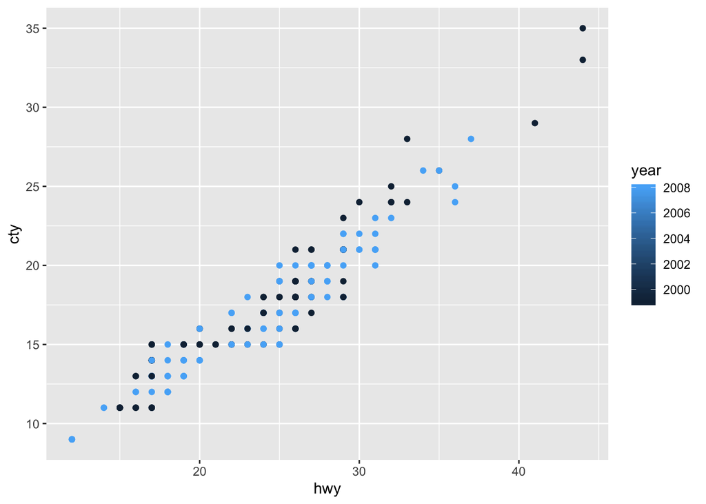

```r
ggplot(data = mpg) +
  geom_point(mapping = aes(x=hwy, y=cty, color=year))
```

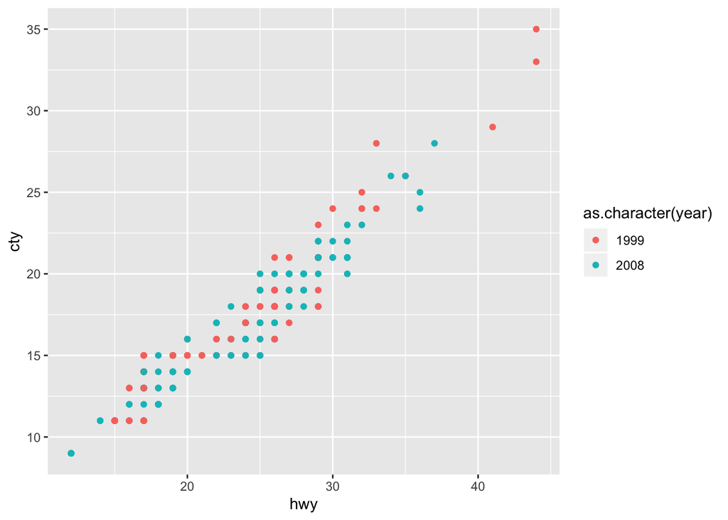

```r
ggplot(data = mpg) +
  geom_point(mapping = aes(x = hwy, y = cty, color = as.character(year)))
```